# Data 621 Final Project: Contract Renewal Predictions

Critical Thinking Group 2 - James Topor, Armenoush Aslanian-Persico, Jeff Nieman, Scott Karr

July 2016

# Part 1: Data Exploration

## Data Dictionary

| Item | Variable.Name | Definition | Theoretical.Effect |
| --- | --- | --- | --- |
| 1 | Index | Unique identifier (key) for a distinct service contract. | None |
| 2 | Area | Location where the service was sold. | Unknown effect |
| 3 | Service Approach | S is a particular service model. All other services are labeled not S. | The theory is that S will be much more effective than anything else we offer. |
| 4 | Channel Approach | We sell services largely through other companies. This reflects two different channel models. | Unknown effect |
| 5 | Renewal Flag | The key variable  whether or not a contract renewed. If it did not renew it is now an expired contract representing lost business. | N/A - Variable to predict |
| 6 | Contract Expiration Date | The date the contract expired or if renewed when it will expire. | Unknown effect |
| 7 | Contract Length | Annual or multi-year renewal. | Multi-year contracts may be more likely to renew. |
| 8 | Sales Category | Different categories of clients. | Unknown effect |
| 9 | Seller Unique ID | Unique idenitfier for the actual seller of the service on behalf of the company. | Certain sellers may be more likely to renew. |
| 10 | Contract Value Category | Buckets for contract value based on net (i.e. discounted price). | Discounted contracts may be more likely to renew. |
| 11 | Contract Line Category | Buckets based on items on the contract. Less than 10 is very small, 10-49 is small, 50-99 is medium, 100-999 is large and greater than 999 is very large. | Contracts with more items may be more likely torenew. |
| 12 | Discount Category | Buckets representining the amount of discount applied from the catalogue price of the contract. Discounts are earned based on loyalty, length of contract, system configuration and geography. | Discounted contracts may be more likely to renew. |
| 13 | Multiple Services | Flag to call out whether there is more than one service approach on the contract. When there is more than 1 the highest value service is called out in the Service Approach column. | Unknown effect |
| 14 | Item Count | Count of the items under service on the contract. | Contracts with more items may be more likely torenew. |
| 15 | Cost | Catalogue cost for the service requested on the items of the contract. | Unknown effect |

## Summary Statistics

```
##      INDEX                    AREA       SERVICE_APPROACH CHANNEL_APPROACH
##  Min.   :    1   USA            :67978   NOT S:32817      FIRST :43042
##  1st Qu.:22932   CANADA         : 6679   S    :58909      SECOND:48684
##  Median :45864   US_CANADA_OTHER: 5019
##  Mean   :45864   BRASIL         : 3059
##  3rd Qu.:68795   CANSAC         : 2878
##  Max.   :91726   MCO            : 2672
##                  (Other)        : 3441
##   RENEWAL_FLAG   CONTRACT_EXPIRATION   CONTRACT_LENGTH  SALES_CATEGORY
##  Min.   :0.000   7/31/2015 : 4475    ANNUAL    :75975   COM  :60259
##  1st Qu.:0.000   12/31/2015: 2843    MULTI-YEAR:15751   ENT  : 7025
##  Median :0.000   12/31/2016: 1938                       OTHER: 6562
##  Mean   :0.319   3/31/2016 : 1470                       PS   :17571
##  3rd Qu.:1.000   10/31/2016: 1425                       SMB  :    1
##  Max.   :1.000   9/30/2015 : 1230                       SP   :  308
##                  (Other)   :78345
##  SELLER_UNIQUE_ID CONTRACT_VALUE_CATEGORY CONTRACT_LINE_CATEGORY
##  54     : 8773    <10K     :80500         LARGE     : 2601
##  4139   : 3387    >250K    :  441         MEDIUM    : 2190
##  #VALUE!: 3026    100K-250K:  826         SMALL     :12182
##  47796  : 1712    10K-25K  : 6045         VERY LARGE:  262
##  29543  : 1521    25K-50K  : 2551         VERY SMALL:74491
##  15617  : 1367    50K-100K : 1363
##  (Other):71940
##    DISCOUNT_CATEGORY MULTIPLE_SERVICES   ITEM_COUNT             COST
##  #DIV/0!    :  146   NO :91009         Min.   :    1.00   $101.00 :  955
##  LARGE      :23028   YES:  717         1st Qu.:    1.00   $69.00  :  902
##  MEDIUM     :42578                     Median :    2.00   $119.00 :  730
##  NO DISCOUNT:16029                     Mean   :   22.71   $71.00  :  638
##  VERY LARGE : 9945                     3rd Qu.:    6.00   $203.00 :  502
##                                        Max.   :84184.00   $100.00 :  457
##                                                           (Other) :87542
##  SALES_STRATEGY
##  GCS    :71126
##  NOT GCS:20600
##
##
##
##
##
```

| INDEX | AREA | SERVICE_APPROACH | CHANNEL_APPROACH | RENEWAL_FLAG | CONTRACT_EXPIRATION | CONTRACT_LENGTH | SALES_CATEGORY | SELLER_UNIQUE_ID | CONTRACT_VALUE_CATEGORY | CONTRACT_LINE_CATEGORY | DISCOUNT_CATEGORY | MULTIPLE_SERVICES | ITEM_COUNT | COST | SALES_STRATEGY |
| --- | --- | --- | --- | --- | --- | --- | --- | --- | --- | --- | --- | --- | --- | --- | --- |
| 1 | USA | S | FIRST | 1 | 12/29/2015 | ANNUAL | ENT | 54 | 25K-50K | SMALL | LARGE | NO | 38 | $63,958.00 | NOT GCS |
| 2 | USA | S | FIRST | 1 | 9/30/2016 | ANNUAL | PS | 47796 | <10K | SMALL | VERY LARGE | NO | 14 | $18,966.00 | NOT GCS |
| 3 | USA | S | SECOND | 0 | 7/31/2015 | ANNUAL | COM | 1611 | <10K | SMALL | NO DISCOUNT | NO | 11 | $5,518.00 | GCS |
| 4 | USA | S | SECOND | 0 | 9/30/2015 | ANNUAL | PS | -989 | 25K-50K | SMALL | LARGE | NO | 18 | $62,150.00 | NOT GCS |
| 5 | USA | S | FIRST | 0 | 1/19/2016 | ANNUAL | ENT | 24116 | 25K-50K | SMALL | NO DISCOUNT | NO | 17 | $18,870.56 | NOT GCS |
| 6 | USA | S | SECOND | 1 | 12/22/2016 | ANNUAL | COM | 25276 | <10K | VERY SMALL | MEDIUM | NO | 9 | $10,682.00 | GCS |

```r
#basicStats(fp1)
```

Our data set contains recent service contracts with Company X, some of which were renewed and some which were not renewed. Our goal is to predict whether a service contract will be renewed based on the attributes in the data set. A renewal is considered successful.

There are 91726 rows of data, each representing a service contract with Company X.

We have 15 potential predictor variables and one response variable (“RENEWAL_FLAG”) that indicates if the contract was renewed.

## Boxplots and Mosaic Plots

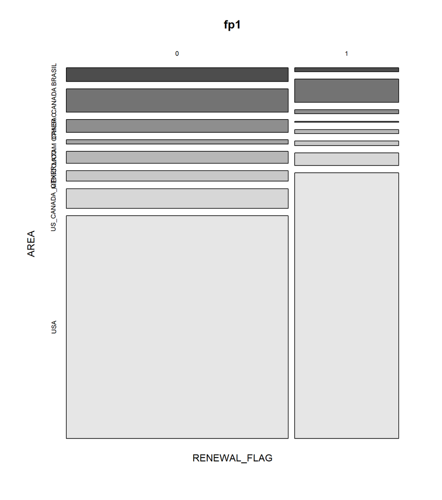

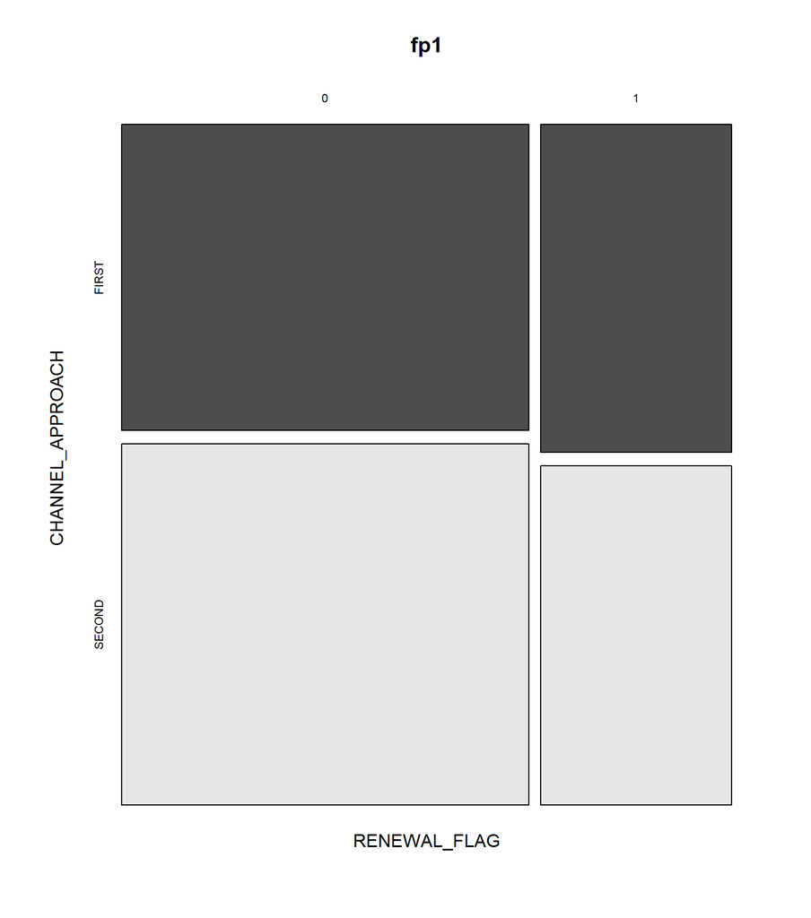

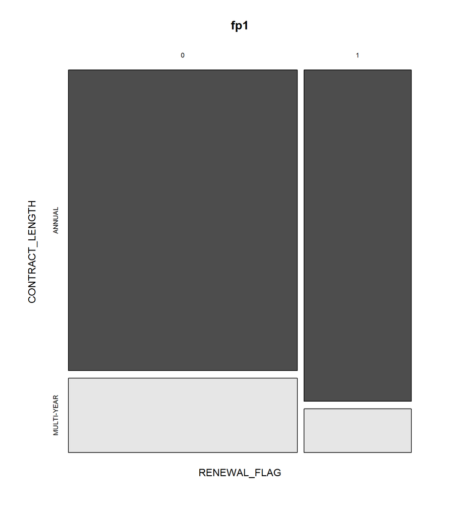

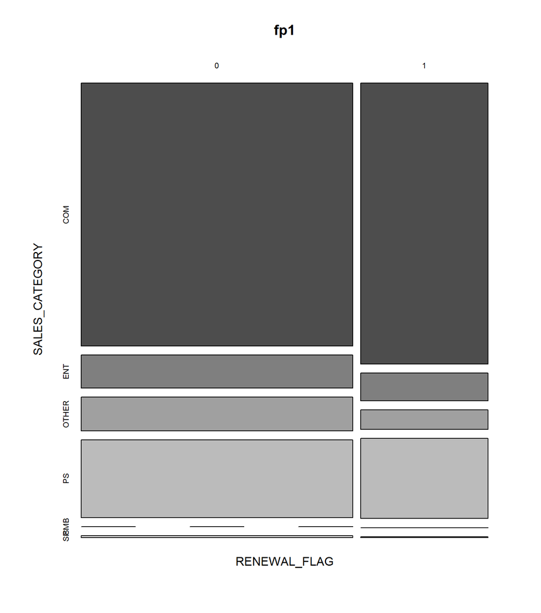

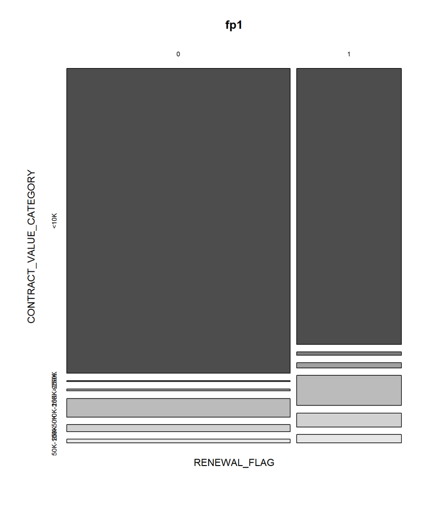

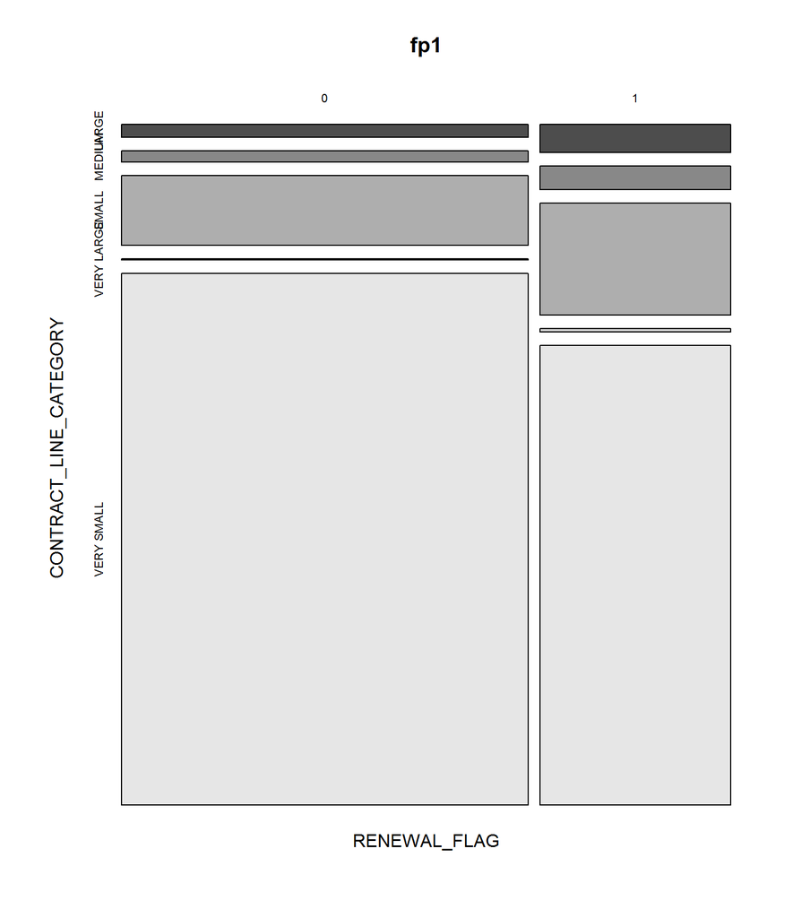

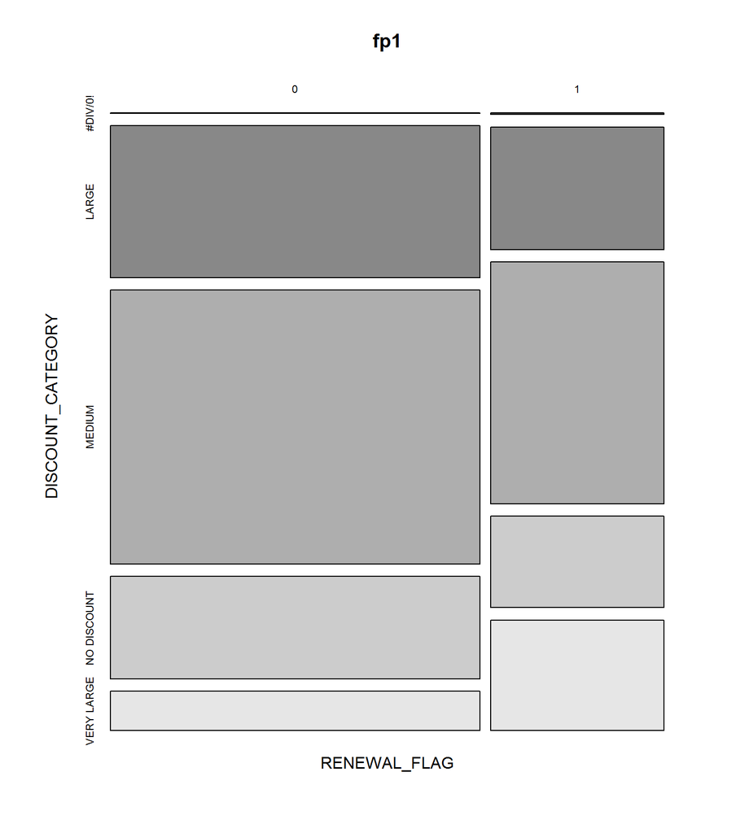

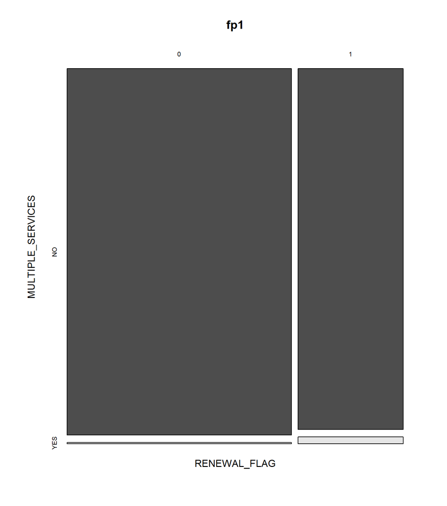

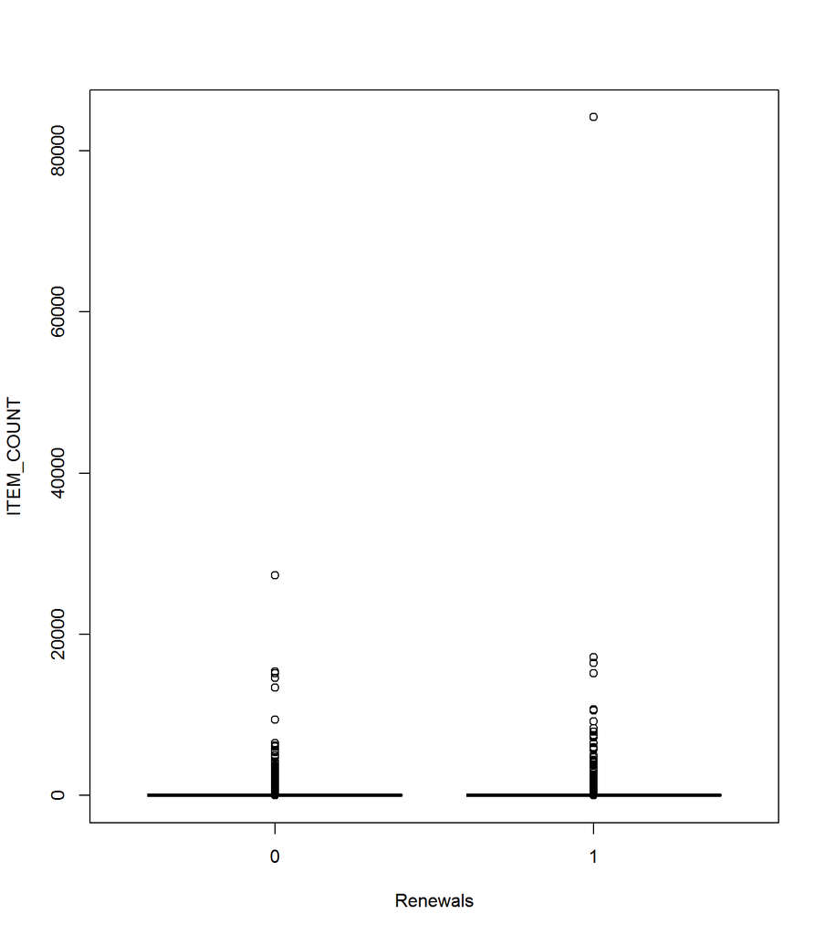

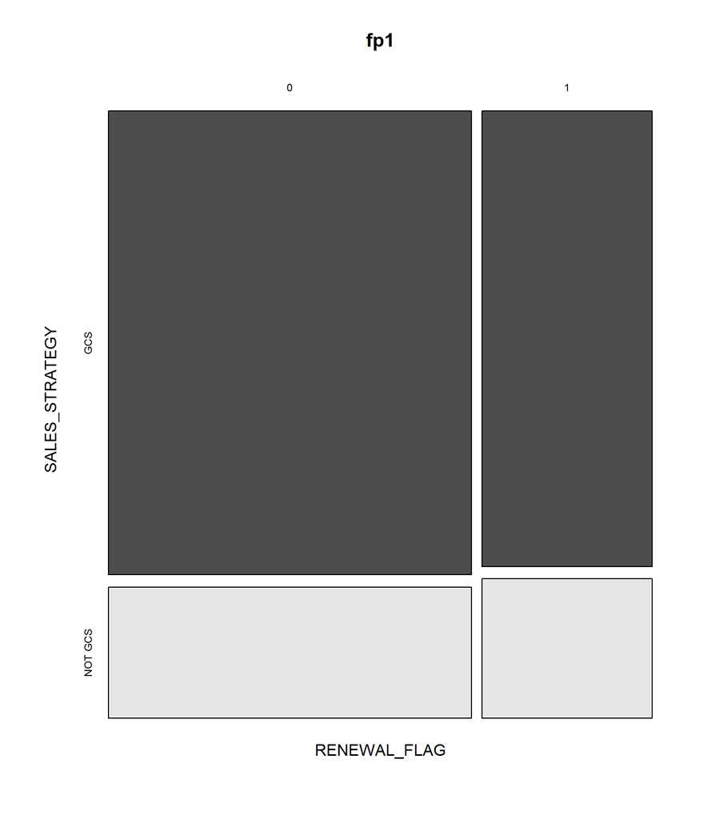

# Part 2: Data Preparation

## Variables to be Transformed

```r
fp.data <- read.csv("c:/users/hammer/documents/Data Science Docs/CUNY MSDA 621/Summer 2016/Final Project/fin proj.csv", stringsAsFactors = FALSE)

# create a copy of the original data to use for transforming individual variables
fp.t <- fp.data
```

```r
# load packages
```

start our data transformation….

1. Area - go for USA=1 and not USA = 2

```r
# transform AREA: USA = 1; !USA = 2

fp.t$AREA[which(fp.data$AREA == 'USA')] <- 1
fp.t$AREA[which(fp.data$AREA != 'USA')] <- 2

# now convert column to numeric since it is char
fp.t$AREA <- as.numeric(fp.t$AREA)

# check results
summary(fp.t$AREA)
```

2. SERVICE_APPROACH - go for Service Approach S=1 or not S = 0

```r
# transform SERVICE_APPROACH: S = 1; !S = 0

fp.t$SERVICE_APPROACH[which(fp.data$SERVICE_APPROACH == 'S')] <- 1
fp.t$SERVICE_APPROACH[which(fp.data$SERVICE_APPROACH != 'S')] <- 0

# now convert column to numeric since it is char
fp.t$SERVICE_APPROACH <- as.numeric(fp.t$SERVICE_APPROACH)

# check results
summary(fp.t$SERVICE_APPROACH)
```

3. CHANNEL_APPROACH - call it tier with second =1 and first =0

```r
# transform CHANNEL: rename to TIER with second = 1; first = 0

fp.t$CHANNEL_APPROACH[which(fp.data$CHANNEL_APPROACH == 'SECOND')] <- 1
fp.t$CHANNEL_APPROACH[which(fp.data$CHANNEL_APPROACH == 'FIRST')] <- 0

# now convert column to numeric since it is char
fp.t$CHANNEL_APPROACH <- as.numeric(fp.t$CHANNEL_APPROACH)

# check results
summary(fp.t$CHANNEL_APPROACH)

# now rename column to TIER
colnames(fp.t)[colnames(fp.t)=="CHANNEL_APPROACH"] <- "TIER"

head(fp.t$TIER)
```

4. RENEWAL_FLAG - renewed = 1, not renewed = 0

```r
# transform RENEWAL_FLAG: RENEWED = 1; NOT RENEWED = 0

fp.t$RENEWAL_FLAG[which(fp.data$RENEWAL_FLAG == 'RENEWED')] <- 1
fp.t$RENEWAL_FLAG[which(fp.data$RENEWAL_FLAG == 'NOT RENEWED')] <- 0

# now convert column to numeric since it is char
fp.t$RENEWAL_FLAG <- as.numeric(fp.t$RENEWAL_FLAG)

# check results
summary(fp.t$RENEWAL_FLAG)
```

5. Contract expiration date - ignore

**NO ACTION TAKEN**

6. CONTRACT_LENGTH - could go with annual = 1 and multi-year = 3 (most common value for each)

```r
# transform CONTRACT_LENGTH: ANNUAL = 1; MULTI-YEAR = 3

fp.t$CONTRACT_LENGTH[which(fp.data$CONTRACT_LENGTH == 'ANNUAL')] <- 1
fp.t$CONTRACT_LENGTH[which(fp.data$CONTRACT_LENGTH == 'MULTI-YEAR')] <- 3

# now convert column to numeric since it is char
fp.t$CONTRACT_LENGTH <- as.numeric(fp.t$CONTRACT_LENGTH)

# check results
summary(fp.t$CONTRACT_LENGTH)
```

7. Sales category - would separate into 3 new columns - ENT = 1, not ENT = 0, PS = 1, not PS=0, COM = 1, not COM = 0

```r
# transform SALES_CATEGORY - create 3 new columns COM, ENT, PS

# build COM column
# first check count of COM entries
sum(fp.data$SALES_CATEGORY == 'COM')

fp.t$COM <- 0
fp.t$COM[fp.data$SALES_CATEGORY == 'COM'] <- 1
# make sure new column matches original
sum(fp.t$ENT == 1)

# ---------------------------------
# build ENT column
sum(fp.data$SALES_CATEGORY == 'ENT')

fp.t$ENT <- 0
fp.t$ENT[fp.data$SALES_CATEGORY == 'ENT'] <- 1
sum(fp.t$ENT == 1)

# ---------------------------------
# build PS column
sum(fp.data$SALES_CATEGORY == 'PS')

fp.t$PS <- 0
fp.t$PS[fp.data$SALES_CATEGORY == 'PS'] <- 1
sum(fp.t$PS == 1)
```

8. Seller_unique ID - not relevant for binary conversation - too complex

**NO ACTION TAKEN**

9. CONTRACT_VALUE_CATEGORY - going to bet it is collinear with cost and can be ignored - or could rank 1 to 5 lowest to highest buckets

```r
# transform CONTRACT_VALUE_CATEGORY: <10k = 0, 10K-25K = 1, etc..

fp.t$CONTRACT_VALUE_CATEGORY[which(fp.data$CONTRACT_VALUE_CATEGORY == '<10K')] <- 0
fp.t$CONTRACT_VALUE_CATEGORY[which(fp.data$CONTRACT_VALUE_CATEGORY == '10K-25K')] <- 1
fp.t$CONTRACT_VALUE_CATEGORY[which(fp.data$CONTRACT_VALUE_CATEGORY == '25K-50K')] <- 2
fp.t$CONTRACT_VALUE_CATEGORY[which(fp.data$CONTRACT_VALUE_CATEGORY == '50K-100K')] <- 3
fp.t$CONTRACT_VALUE_CATEGORY[which(fp.data$CONTRACT_VALUE_CATEGORY == '100K-250K')] <- 4
fp.t$CONTRACT_VALUE_CATEGORY[which(fp.data$CONTRACT_VALUE_CATEGORY == '>250K')] <- 5

# now convert column to numeric since it is char
fp.t$CONTRACT_VALUE_CATEGORY <- as.numeric(fp.t$CONTRACT_VALUE_CATEGORY)

# check results
summary(fp.t$CONTRACT_VALUE_CATEGORY)
```

10. CONTRACT_LINE_CATEGORY- going to bet it is collinear with item count and can be ignored - or could rank 1 to 5 with lowest to highest category

```r
# transform CONTRACT_LINE_CATEGORY: VERY SMALL = 1, SMALL = 2, MEDIUM = 3, LARGE = 4,
# VERY LARGE = 5

fp.t$CONTRACT_LINE_CATEGORY[which(fp.data$CONTRACT_LINE_CATEGORY == 'VERY SMALL')] <- 1
fp.t$CONTRACT_LINE_CATEGORY[which(fp.data$CONTRACT_LINE_CATEGORY == 'SMALL')] <- 2
fp.t$CONTRACT_LINE_CATEGORY[which(fp.data$CONTRACT_LINE_CATEGORY == 'MEDIUM')] <- 3
fp.t$CONTRACT_LINE_CATEGORY[which(fp.data$CONTRACT_LINE_CATEGORY == 'LARGE')] <- 4
fp.t$CONTRACT_LINE_CATEGORY[which(fp.data$CONTRACT_LINE_CATEGORY == 'VERY LARGE')] <- 5

# now convert column to numeric since it is char
fp.t$CONTRACT_LINE_CATEGORY <- as.numeric(fp.t$CONTRACT_LINE_CATEGORY)

# check results
summary(fp.t$CONTRACT_LINE_CATEGORY)
```

11. DISCOUNT_CATEGORY - could go with no or some or call no 0, small 10, medium 20, large 30, very large 50

```r
# transform CONTRACT_LINE_CATEGORY: NO DISCOUNT = 0, SMALL = 10, MEDIUM = 20, LARGE = 30,
# VERY LARGE = 50

fp.t$DISCOUNT_CATEGORY[which(fp.data$DISCOUNT_CATEGORY == 'NO DISCOUNT')] <- 0
fp.t$DISCOUNT_CATEGORY[which(fp.data$DISCOUNT_CATEGORY == 'MEDIUM')] <- 20
fp.t$DISCOUNT_CATEGORY[which(fp.data$DISCOUNT_CATEGORY == 'LARGE')] <- 30
fp.t$DISCOUNT_CATEGORY[which(fp.data$DISCOUNT_CATEGORY == 'VERY LARGE')] <- 50

# now convert column to numeric since it is char
fp.t$DISCOUNT_CATEGORY <- as.numeric(fp.t$DISCOUNT_CATEGORY)

# check results
summary(fp.t$DISCOUNT_CATEGORY)
```

11, MULTIPLE_SERVICES = Yes = 1 and No = 0

```r
# transform MULTIPLE_SERVICES: YES = 1; NO = 0

fp.t$MULTIPLE_SERVICES[which(fp.data$MULTIPLE_SERVICES == 'YES')] <- 1
fp.t$MULTIPLE_SERVICES[which(fp.data$MULTIPLE_SERVICES == 'NO')] <- 0

# now convert column to numeric since it is char
fp.t$MULTIPLE_SERVICES <- as.numeric(fp.t$MULTIPLE_SERVICES)

# check results
summary(fp.t$MULTIPLE_SERVICES)
```

12. SALES_STRATEGY - GCS = 1, not GCS = 0

```r
# transform SALES_STRATEGY: GCS = 1; NOT GCS = 0

fp.t$SALES_STRATEGY[which(fp.data$SALES_STRATEGY == 'GCS')] <- 1
fp.t$SALES_STRATEGY[which(fp.data$SALES_STRATEGY == 'NOT GCS')] <- 0

# now convert column to numeric since it is char
fp.t$SALES_STRATEGY <- as.numeric(fp.t$SALES_STRATEGY)

# check results
summary(fp.t$SALES_STRATEGY)
```

Now write transformed data set to a file

```r
write.csv(fp.t, file = "C:/SQLData/621-FP-Transformed-Data.csv", row.names = FALSE)
```

## Missing Data to be Imputed

The transformed data set can be seen here:

https://raw.githubusercontent.com/spsstudent15/2016-02-621-W2/master/621-FP-Transformed-Data.csv